# Portfoliomanagement and Financial Analysis - Assignment 3

## Exercise 3: Covariance Problems

In the first part of this exercise we will be checking covariances and portfolios that might occur from faulty correlation matrices. We use the covariance matrix from our example

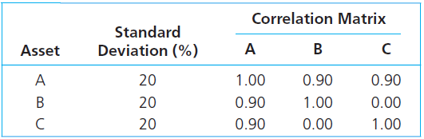

where we additionally assume mean returns of 10% for all three assets. If we define $\mu$ to be the vector of mean returns and $\sigma$ the vector of standard deviations, we can calculate the covariance matrix $\Sigma$ as $\Sigma=diag(\sigma)\cdot R\cdot diag(\sigma)$, where $R$ is the correlation matrix (as in the table above) and $diag$ puts the three standard deviations into the diagonal of a matrix.

First, we create the correlation-matrix “R” with the values from above.

```r
x1 <- c(1.00, 0.90, 0.90, 0.90, 1.00, 0.00, 0.90, 0.00, 1.00)
R <- matrix(x1, 3)
colnames(R) <- c("A", "B", "C")
rownames(R) <- c("A", "B", "C")
R
```

```
    A   B   C
A 1.0 0.9 0.9
B 0.9 1.0 0.0
C 0.9 0.0 1.0
```

Now, we set mu=10%=0.1 and sigma=20%=0.2

```r
mu <- matrix(c(.1, .1, .1), 3)
sd <- matrix(c(.20, .20, .20), 3)
mu
```

```
     [,1]
[1,]  0.1
[2,]  0.1
[3,]  0.1
```

```r
sd
```

```
     [,1]
[1,]  0.2
[2,]  0.2
[3,]  0.2
```

Now, we create the covariance-matrix.

```r
covariance_matrix <- diag(sd)*R*diag(sd)
covariance_matrix
```

```
      A     B     C
A 0.040 0.036 0.036
B 0.036 0.040 0.000
C 0.036 0.000 0.040
```

Now we can calculate the Minimum-Variance-Portfolio using matrix calculus as $w_MP=\frac{\Sigma^{-1}\cdot 1'}{1\cdot\Sigma^{-1}\cdot 1'}$ where 1 is a vector of ones with dimension equal to the number of assets.

Calculating the Mimimum-Variance-Portfolio.

```r
onevector <- matrix(c(1, 1, 1), 1)
wmvpcalctop <- solve(covariance_matrix)%*%t(onevector)
wmvpcalcbottom <- as.numeric(onevector%*%solve(covariance_matrix)%*%t(onevector))
wmvp <- wmvpcalctop/wmvpcalcbottom
wmvp
```

```
        [,1]
A  1.3333333
B -0.1666667
C -0.1666667
```

Similarly one can calculate the tangency portfolio as $w_TP=\frac{\Sigma^{-1}\cdot (\mu-r_f)'}{1\cdot\Sigma^{-1}\cdot (\mu-r_f)'}$.

We set the tangency portfolio risk free rate = 3% = 0.03

```r
wtpcalctop <- (solve(covariance_matrix)%*%(mu-0.03))
wtpcalcbottom <- as.numeric(onevector%*%solve(covariance_matrix)%*%(mu-0.03))
wtp <- wtpcalctop/wtpcalcbottom
wtp #Weights equal to MVP
```

```
        [,1]
A  1.3333333
B -0.1666667
C -0.1666667
```

Now we can calculate the Minimum-Variance-Portfolio using matrix calculus as $w_MP=\frac{\Sigma^{-1}\cdot 1'}{1\cdot\Sigma^{-1}\cdot 1'}$ where 1 is a vector of ones with dimension equal to the number of assets. Similarly one can calculate the tangency portfolio as $w_TP=\frac{\Sigma^{-1}\cdot (\mu-r_f)'}{1\cdot\Sigma^{-1}\cdot (\mu-r_f)'}$.

So to get used to the necessary tools, we use the package “matrixcalc” wherein we have a function `is.positive.semi.definite()` that can check covariance/correlation matrices for positive semidefiniteness. In the package `Matrix` we find a function `nearPD` that can help us to create a valid correlation matrix. Try and calculate the weights of the MVP and the TP, and then calculate portfolio mean and variance using $\mu_P=w\cdot \mu'$ and $\sigma_P^2=w\cdot \Sigma\cdot w'$ for the MVP and the TP as well as the weight vector w=(-1,1,1). Do this for the faulty matrix as well as the corrected one. What do you observe?

Now we do a test in order to answer the following question: Are the Matrices definite? As we can see, they are not.

```r
is.positive.semi.definite(R)
```

```
[1] FALSE
```

```r
is.positive.definite(covariance_matrix)
```

```
[1] FALSE
```

Now, we want to compute the nearest positive definite matrix with the help of nearPD and create a new covariance matrix.

```r
R2 <- nearPD(R,keepDiag = TRUE)
R2 <- matrix(c( 1.00000, 0.74341, 0.74341,
                0.74341, 1.00000, 0.10532,
                0.74341, 0.10532, 1.00000)
             , 3)

covmat2 <- diag(sd)*R2*diag(sd)
```

Now, we test it again to see if it worked - and it did work!

```r
is.positive.definite(R2)
```

```
[1] TRUE
```

```r
is.positive.definite(covmat2)
```

```
[1] TRUE
```

Next, we calculate the new minimum variance portfolio

```r
wmvpcalctop2 <- solve(covmat2)%*%t(onevector)
wmvpcalcbottom2 <- as.numeric(onevector%*%solve(covmat2)%*%t(onevector))
wmvp2 <- wmvpcalctop2/wmvpcalcbottom2
wmvp2
```

```
          [,1]
[1,] -2.897175
[2,]  1.948587
[3,]  1.948587
```

Now, we calculate mu. Mu did not change, it still is 10%.

```r
mumvp <- t(wmvp)%*%mu
mumvp2 <- wmvp2[,1]%*%mu
mumvp2 #Mu didn't change, still 10
```

```
     [,1]
[1,]  0.1
```

```r
sdmvpcalc <- t(wmvp)%*%R%*%wmvp
sdmvp <- sqrt(sdmvpcalc)
sdmvpcalc2 <- t(wmvp2)%*%R2%*%wmvp2
sdmvp2 <- sqrt(sdmvpcalc2)
sdmvp2 #Standard Deviation didn't change, still .48%
```

```
            [,1]
[1,] 0.004886158
```

Now, we calculate the new tangency portfolio. The weights again equal to MVP.

```r
wtpcalctop2 <- (solve(covmat2)%*%(mu-0.03))
wtpcalcbottom2 <- as.numeric(onevector%*%solve(covmat2)%*%(mu-0.03))
wtp2 <- wtpcalctop2/wtpcalcbottom2
wtp2 #Weights again equal to MVP
```

```
          [,1]
[1,] -2.897175
[2,]  1.948587
[3,]  1.948587
```

Now, we calculate mu. Mu is still 10% and did not change.

```r
muwtp <- t(wtp)%*%mu
muwtp2 <- wtp2[,1]%*%mu
muwtp2 #Mu didn't change, still 10%
```

```
     [,1]
[1,]  0.1
```

```r
sdwtpcalc <- t(wtp)%*%R%*%wtp
sdwtp <- sqrt(sdwtpcalc)
sdwtpcalc2 <- t(wtp2)%*%R2%*%wtp2
sdwtp2 <- sqrt(sdwtpcalc2)
sdwtp2 #Standard Deviation didn't change, still .48%
```

```
            [,1]
[1,] 0.004886158
```

For the -1,1,1 portfolio, we create the vector weights.

```r
wv <- matrix(c(-1, 1, 1),3)
wv
```

```
     [,1]
[1,]   -1
[2,]    1
[3,]    1
```

Now, we calculate mu.

```r
muwv <- wv[,1]%*%mu
muwv
```

```
     [,1]
[1,]  0.1
```

Next, we calculate the standard deviation.

```r
sdwvcalc <- t(wv)%*%R%*%wv
sdwv <- sqrt(sdwvcalc) #In sqrt(sdwvcalc) : NaNs produced
```

```
NaNs produced
```

```r
stdmvpcalc3 <- t(wmvp2)%*%R2%*%wmvp2
sdwvcalc <- t(wmvp2)%*%R2%*%wmvp2
sdwv2 <- sqrt(stdmvpcalc3)
sdwv2 #Standard Deviation also .48%
```

```
            [,1]
[1,] 0.004886158
```